# Competing Risks2026 Practicals IV

Author

Ronald Geskus

Published

### Data

In the competing risks practical, we only use information on relapse and death. We investigate the role of the EBMT risk score, but we correct for age as a possible confounder. The EBMT score is a combination of donor-recipient match and age of the recipient, among other things. It divides patients into three risk groups. The event time and event status are in the columns `srv` and `srvstat`.

- We again load the packages and the data

```r
library(mstate)
library(ggsurvfit)
library(survminer)
data(ebmt1)
ebmt1 <- within(ebmt1,{
  time <- pmin(srv,rel)/365.25
  stat <-  ifelse(rel<srv,relstat,srvstat*2) #relapse=1, death=2
  type <- factor(stat,
               labels=c("Event-free","Relapse","Death"))
})
Webmt.score <- crprep(Tstop="time", status="type", data=ebmt1,
                      trans=c("Relapse","Death"), cens="Event-free", id="patid",
                      keep=c("score","age","type","stat"), strata="score")
Webmt <- crprep(Tstop="time", status="type", data=ebmt1,
                      trans=c("Relapse","Death"), cens="Event-free", id="patid",
                      keep=c("score","age","type","stat"))
```

### 11. Impact of EBMT score on subdistribution hazards

- Fit a proportional subdistribution hazards model for the impact of score on both relapse and death as first event. Compare results with those from the proportional cause-specific hazards model. Use the weights that do not depend on score[^1] (using score-specific weights hardly changes results).

```r
fitsdh.rel <- coxph(Surv(Tstart,Tstop,status==1)~score,
                                      data=Webmt, subset=failcode=="Relapse", weights=weight.cens)
fitsdh.death <- coxph(Surv(Tstart,Tstop,status==2)~score,
                                      data=Webmt, subset=failcode=="Death", weights=weight.cens)
fitsdh.rel
```

```
Call:
coxph(formula = Surv(Tstart, Tstop, status == 1) ~ score, data = Webmt,
    weights = weight.cens, subset = failcode == "Relapse")

                 coef exp(coef) se(coef)  z  p
scoreMedium risk   NA        NA        0 NA NA
scoreHigh risk     NA        NA        0 NA NA

Likelihood ratio test=0  on 0 df, p=1
n= 94284, number of events= 0
```

```r
fitsdh.death
```

```
Call:
coxph(formula = Surv(Tstart, Tstop, status == 2) ~ score, data = Webmt,
    weights = weight.cens, subset = failcode == "Death")

                 coef exp(coef) se(coef)  z  p
scoreMedium risk   NA        NA        0 NA NA
scoreHigh risk     NA        NA        0 NA NA

Likelihood ratio test=0  on 0 df, p=1
n= 33446, number of events= 0
```

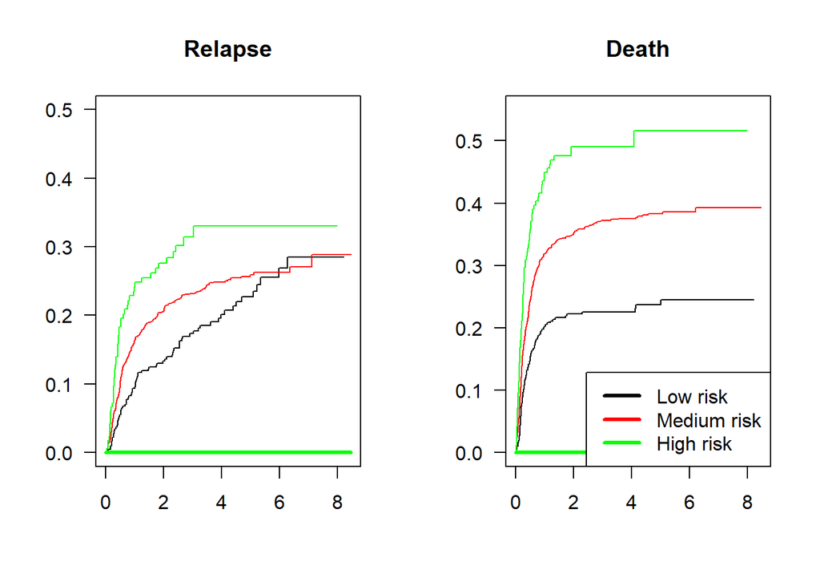

```r
indivs <- data.frame(score=levels(ebmt1$score))
par(mfrow=c(1,2),las=1)
pred.sdh <- survfit(fitsdh.rel, newdata=indivs)
plot(survfit(Surv(Tstart,Tstop,status=="Relapse")~score,
             data=subset(Webmt.score,failcode=="Relapse"), weights=weight.cens), lwd=1,
     col=c("black","red","green"), fun="event", ylim=c(0,0.5))
lines(pred.sdh,fun="event", col=c("black","red","green"), lwd=3)
title("Relapse")
pred.sdh <- survfit(fitsdh.death, newdata=indivs)
plot(survfit(Surv(Tstart,Tstop,status=="Death")~score,
             data=subset(Webmt.score,failcode=="Death"), weights=weight.cens), lwd=1,
             col=c("black","red","green"), fun="event", ylim=c(0,0.55))
lines(pred.sdh,fun="event", col=c("black","red","green"), lwd=3)
title("Death")
legend("bottomright", levels(ebmt1$score), col=c("black","red","green"), lwd=3 )
```

### 12. Regression on cause-specific hazard, combined analysis

- Combine the effect of EBMT risk score on both events in one analysis. Check whether results coincide with the ones from the separate analyses.

We can create the stacked data set and add a column that specifies the type of end point as follows

```r
tmp1 <- cbind(ebmt1,failcode=1)
tmp2 <- cbind(ebmt1,failcode=2)
ebmt.stack <- rbind(tmp1,tmp2)
```

However, if we use the data set created by the `crprep` function, then we already have such data set, and we can fit both a regression model for the cause-specific hazard as well as for the subdistribution hazrd.

For the cause-specific hazard, we restrict to the rows with `count==1`. These are the rows that represent the observed follow-up, and all weights have the value of one.

```r
coxph(Surv(Tstop,status==failcode)~strata(failcode)*score, data=Webmt, subset=count==1)
```

```
Call:
coxph(formula = Surv(Tstop, status == failcode) ~ strata(failcode) *
    score, data = Webmt, subset = count == 1)

                                             coef exp(coef) se(coef)      z        p
scoreMedium risk                          0.63930   1.89515  0.11332  5.642 1.69e-08
scoreHigh risk                            1.17824   3.24865  0.15341  7.680 1.59e-14
strata(failcode)Relapse:scoreMedium risk -0.20743   0.81267  0.16911 -1.227    0.220
strata(failcode)Relapse:scoreHigh risk   -0.09275   0.91142  0.23873 -0.389    0.698

Likelihood ratio test=95.94  on 4 df, p=< 2.2e-16
n= 3954, number of events= 1141
```

Since EBMT score is a categorical variable, we can also perform the analysis via a compound score variable. We allow for separate baseline hazards for each end point, which are the hazards for the reference value of EBMT score (Low risk). Therefore, we only need one level for Low risk. We create four levels that give the contrasts of Medium risk and High risk for each of the two end points. An efficient, although maybe not very insightful way to create one compound score variable is via

```r
Webmt$score.comb <- with(Webmt,
  factor( (as.numeric(score)-1)*(failcode=="Relapse")+
             3*(as.numeric(score)-1)*(failcode=="Death"),
  labels=c("Low","Medium.Rel","High.Rel","Medium.Death","High.Death"))
  )
```

Fit the model via

```r
coxph(Surv(Tstop,status==failcode)~strata(failcode)+ score.comb, data=Webmt, subset=count==1)
```

```
Call:
coxph(formula = Surv(Tstop, status == failcode) ~ strata(failcode) +
    score.comb, data = Webmt, subset = count == 1)

                         coef exp(coef) se(coef)     z        p
score.combMedium.Rel   0.4319    1.5401   0.1255 3.440 0.000581
score.combHigh.Rel     1.0855    2.9609   0.1829 5.934 2.95e-09
score.combMedium.Death 0.6393    1.8951   0.1133 5.642 1.69e-08
score.combHigh.Death   1.1782    3.2487   0.1534 7.680 1.59e-14

Likelihood ratio test=95.94  on 4 df, p=< 2.2e-16
n= 3954, number of events= 1141
```

When fitting the model with the combined score variable, the values in `score.comb` are internally transformed into four columns with dummy variables. These are the type-specific variables. We can create them via

```r
Webmt$Medium.Rel <- with(Webmt,
                              ifelse(score=="Medium risk"&failcode=="Relapse", 1, 0))
Webmt$High.Rel <- with(Webmt,
                            ifelse(score=="High risk"&failcode=="Relapse", 1, 0))
Webmt$Medium.Mort <- with(Webmt,
                               ifelse(score=="Medium risk"&failcode=="Death", 1, 0))
Webmt$High.Mort <- with(Webmt,
                             ifelse(score=="High risk"&failcode=="Death", 1, 0))
```

The model with these variables is fitted via

```r
fit.csh.comb <- coxph(Surv(Tstop,status==failcode)~strata(failcode)+
                          Medium.Rel+High.Rel+Medium.Mort+High.Mort, data=Webmt, subset=count==1)
fit.csh.comb
```

```
Call:
coxph(formula = Surv(Tstop, status == failcode) ~ strata(failcode) +
    Medium.Rel + High.Rel + Medium.Mort + High.Mort, data = Webmt,
    subset = count == 1)

              coef exp(coef) se(coef)     z        p
Medium.Rel  0.4319    1.5401   0.1255 3.440 0.000581
High.Rel    1.0855    2.9609   0.1829 5.934 2.95e-09
Medium.Mort 0.6393    1.8951   0.1133 5.642 1.69e-08
High.Mort   1.1782    3.2487   0.1534 7.680 1.59e-14

Likelihood ratio test=95.94  on 4 df, p=< 2.2e-16
n= 3954, number of events= 1141
```

Apart from the naming of the variables, the output is the same as when the compound variable is used. We store this output in `fit.csh.comb` for later use.

### 13. Test for equality of effects

- We already observed that the effects of Medium risk and High risk on both event types were comparable. We now formally test for equality.

```r
coxph(Surv(Tstop,status==failcode)~strata(failcode)+score+Medium.Mort+High.Mort,
                                                  data=Webmt, subset=count==1)
```

```
Call:
coxph(formula = Surv(Tstop, status == failcode) ~ strata(failcode) +
    score + Medium.Mort + High.Mort, data = Webmt, subset = count ==
    1)

                    coef exp(coef) se(coef)     z        p
scoreMedium risk 0.43186   1.54013  0.12553 3.440 0.000581
scoreHigh risk   1.08549   2.96089  0.18292 5.934 2.95e-09
Medium.Mort      0.20743   1.23052  0.16911 1.227 0.219974
High.Mort        0.09275   1.09719  0.23873 0.389 0.697640

Likelihood ratio test=95.94  on 4 df, p=< 2.2e-16
n= 3954, number of events= 1141
```

## Footnotes

[^1]: Currently the `finegray` function has a bug in the calculation of covariate specific weights. It does not affect the PL-estimate, but it does affect the Fine and Gray model. See this [issue](https://github.com/therneau/survival/issues/329)